# Airline Customer Satisfaction - Group 17

2025-04-11

# Analyst

| Name | Student Number |
| --- | --- |
| Andra Miftah Ar Rahman | 5728827 |
| Vicky Wijaya | 5795427 |
| Maulvi Azmi Winata | 6146015 |
| Dewi Farra Prasasya | 6171486 |
| Agassi Fathurisma | 6211542 |

# 1 Project Background

## 1.1 Abstract

**Framework for abstract:**

After industry-wide setbacks from the COVID-19 pandemic, the airline industry is experiencing a strong recovery in profitability. According to the International Air Transport Association (IATA), airlines worldwide have seen improved projections since 2024. The market is projected to showcase an annual growth rate (CAGR 2025-2029) of 4.36%, resulting in a projected market volume of US$771.26bn by 2029, worldwide (Statista, 2024). However, low-cost carriers (LCCs) are shifting the traditional perceptions of value and service among travelers by offering lower fares with fewer amenities. As traditional full-service airlines compete in this market environment, understanding the main drivers of customer satisfaction becomes critical to maintain competitiveness.

In this research, we analyze data from over 120,000+ airline passengers, including information on passenger demographics, flight characteristics (delays and distance), as well as service evaluations. Since this data lacks information on the specific airlines and ticket pricing, we will focus on analyzing the service-related factors that universally impact passenger satisfaction. This research aims to **determine the aspects of service that are important towards customer satisfaction.**

In our analysis, we initially explore the dataset to understand the variables and their distributions, as well as detect missing values. Data preparation procedures such as cleaning, normalization, and transformation are conducted before analysis. Modeling is performed by two different methods, decision tree classifier and logistic regression. Both models show a strong fit to the testing data. We further refine the model by utilizing boosting, assigning costs, as well dimensionality reduction. Results from both models converge well in identifying key drivers of satisfaction.

In summary, we find that Economy class passengers make up the majority of dissatisfied customers. However, a significant proportion of Business class travelers also report dissatisfaction. Using logistic regression, we explore the important aspects of service based on passenger class. The impact of each aspect of service were evaluated and ranked based on their magnitude (log-odds). We find that Business class and Economy class passengers had different drivers of satisfaction. For Business class passengers ease of online booking, delays, food and drink, as well as time convenience made up the dominant drivers for dissatisfaction. Whereas for Economy class passengers, in flight service, ease of online booking, and delay status were the dominant negative drivers. The full overview can be seen in Chapter 4.1. Recommendations for each driver are discussed in Chapter 4.2.

## 1.2 Business Problem

In this project, Group 17 serves as business consultants, with a focus on improving customer experience in the industry. Our responsibilities are from analyzing customer satisfaction statistics, developing measures to improve the airline’s overall performance. Therefore, the business problem that we solve is “**How can airlines improve its strategy of services and activities to increase customer satisfaction, especially between segments and main service areas, to achieve stronger competitive advantages?**”.

**The reason why we chose airline industry as our focus :**

- Low-cost carriers (LCCs) are shifting the traditional perceptions of value and service among travelers by offering lower fares with fewer amenities.
- Intense rivalry among airlines could be easily justified by customer satisfaction. Thus, higher customer satisfaction leads to increased client retention and overall business performance.
- Concentrating on major market segments may provide a more general view of the aspects contributing to consumer satisfaction.

**Why focus on customer satisfaction?**

- **Enhance customer loyalty**: improving on these key segments and service areas will enhance customer satisfaction that potentially increases customer loyalty rate.
- **Competitive Advantage**: by addressing the service issue, the airline can stand out from the competitors.

## 1.3 Setting Up the R Workplace

Besides the Basic R Functions, this project uses multiple packages to enhance the R functionalities and improve the data analytics and visualization quality. This section explains all the packages and functions beyond the Basic R functionalities that we are using in this project in each step of the business analytics process from data cleaning to modeling.

- Data Cleaning and Preparation
  - `dplyr` : used to filter rows, select columns, sort data, create new columns, and summarize data.
  - `tidyr` : imported to be used to clean and tidy the data, such as reshaping the data from wide to long format.
- Data Exploration
  - `skimr` : designed to provide summary of statistical measures for each variables in data frames.
  - `DataExplorer` : used to display comprehensive and convenient interface for data exploration and data visualization.
- Data Transformation
- Data Visualization
  - `ggplot2` : a package that is useful to visualize data in a more complex and customizable way compared to the basic R plotting functions.
  - `corrplot` : used to visualize correlation matrix between two variables in a more visually appealing and informative way.
- Data Modeling
  - `caret` : used for the process of creating predictive models, including data splitting, pre-processing, feature selection, and model tuning.
  - `rsample` : a package to create resampling objects for both training and testing datasets.
  - `c50` : used to create decision trees and rule-based models.
  - `gmodel` : designed as a tool for fitting linear models.
  - `ranger` : package for fast implementation of random forests with high cardinality data.
  - `randomForest` : used to create a random forest model for the optimization of classification and decision tree.
  - `pROC` : used to visualize the performance of classification models by plotting the ROC curve and further utilized to calculate the AUC (Area Under the Curve) score.
  - `Information` : used to calculate the Information Value (IV) and Weight of Evidence (WOE) for each variable in the dataset.
- Data Analysis

Below we will find the commands to install the required libraries so that the code can run properly.The libraries only need to be imported only once, later we only need to call the necessary libraries when needed on the specific sections.

```r
# Importing Library

library(dplyr)
library(ggplot2)
library(skimr)
library(DataExplorer)
library(corrplot)
library(tidyr)
library(caret)
library(C50)
library(rsample)
library(gmodels)
library(ranger)
library(randomForest)
library(pROC)
library(Information)
```

## 1.4 Dataset

In this assignment, we use data set of [Airline Passenger Satisfaction Dataset](https://www.kaggle.com/datasets/mysarahmadbhat/airline-passenger-satisfaction) through Kaggle.The data consist of 24 variables from 129,880 passengers. Data cleaning and preparation are required to ensure the data is ready for analysis.

Firstly import all the data, csv file to be used in the data analysis process. The before using the data, it is important to understand all data type included in the data set. Subsequently, understanding statistic profile in the data set could help to prepare the data before using it.

```r
# Read Data
# Please note that the csv needs to be put into the same folders as this file for ensuring everything works properly
# The dataset should be downloaded from the Kaggle, or unzip from our submission in BrightSpace.
data <- read.csv("airline_passenger_satisfaction.csv")

#Understanding the data types
str(data)
```

```
## 'data.frame':    129880 obs. of  24 variables:
##  $ ID                                    : int  1 2 3 4 5 6 7 8 9 10 ...
##  $ Gender                                : chr  "Male" "Female" "Male" "Male" ...
##  $ Age                                   : int  48 35 41 50 49 43 43 60 50 38 ...
##  $ Customer.Type                         : chr  "First-time" "Returning" "Returning" "Returning" ...
##  $ Type.of.Travel                        : chr  "Business" "Business" "Business" "Business" ...
##  $ Class                                 : chr  "Business" "Business" "Business" "Business" ...
##  $ Flight.Distance                       : int  821 821 853 1905 3470 3788 1963 853 2607 2822 ...
##  $ Departure.Delay                       : int  2 26 0 0 0 0 0 0 0 13 ...
##  $ Arrival.Delay                         : int  5 39 0 0 1 0 0 3 0 0 ...
##  $ Departure.and.Arrival.Time.Convenience: int  3 2 4 2 3 4 3 3 1 2 ...
##  $ Ease.of.Online.Booking                : int  3 2 4 2 3 4 3 4 1 5 ...
##  $ Check.in.Service                      : int  4 3 4 3 3 3 4 3 3 3 ...
##  $ Online.Boarding                       : int  3 5 5 4 5 5 4 4 2 5 ...
##  $ Gate.Location                         : int  3 2 4 2 3 4 3 4 1 2 ...
##  $ On.board.Service                      : int  3 5 3 5 3 4 5 3 4 5 ...
##  $ Seat.Comfort                          : int  5 4 5 5 4 4 5 4 3 4 ...
##  $ Leg.Room.Service                      : int  2 5 3 5 4 4 5 4 4 5 ...
##  $ Cleanliness                           : int  5 5 5 4 5 3 4 4 3 4 ...
##  $ Food.and.Drink                        : int  5 3 5 4 4 3 5 4 3 2 ...
##  $ In.flight.Service                     : int  5 5 3 5 3 4 5 3 4 5 ...
##  $ In.flight.Wifi.Service                : int  3 2 4 2 3 4 3 4 4 2 ...
##  $ In.flight.Entertainment               : int  5 5 3 5 3 4 5 3 4 5 ...
##  $ Baggage.Handling                      : int  5 5 3 5 3 4 5 3 4 5 ...
##  $ Satisfaction                          : chr  "Neutral or Dissatisfied" "Satisfied" "Satisfied" "Satisfied" ...
```

```r
# Summary of Data statistics
summary(data)
```

```
##        ID            Gender               Age        Customer.Type
##  Min.   :     1   Length:129880      Min.   : 7.00   Length:129880
##  1st Qu.: 32471   Class :character   1st Qu.:27.00   Class :character
##  Median : 64941   Mode  :character   Median :40.00   Mode  :character
##  Mean   : 64941                      Mean   :39.43
##  3rd Qu.: 97410                      3rd Qu.:51.00
##  Max.   :129880                      Max.   :85.00
##
##  Type.of.Travel        Class           Flight.Distance Departure.Delay
##  Length:129880      Length:129880      Min.   :  31    Min.   :   0.00
##  Class :character   Class :character   1st Qu.: 414    1st Qu.:   0.00
##  Mode  :character   Mode  :character   Median : 844    Median :   0.00
##                                        Mean   :1190    Mean   :  14.71
##                                        3rd Qu.:1744    3rd Qu.:  12.00
##                                        Max.   :4983    Max.   :1592.00
##
##  Arrival.Delay     Departure.and.Arrival.Time.Convenience
##  Min.   :   0.00   Min.   :0.000
##  1st Qu.:   0.00   1st Qu.:2.000
##  Median :   0.00   Median :3.000
##  Mean   :  15.09   Mean   :3.058
##  3rd Qu.:  13.00   3rd Qu.:4.000
##  Max.   :1584.00   Max.   :5.000
##  NA's   :393
##  Ease.of.Online.Booking Check.in.Service Online.Boarding Gate.Location
##  Min.   :0.000          Min.   :0.000    Min.   :0.000   Min.   :0.000
##  1st Qu.:2.000          1st Qu.:3.000    1st Qu.:2.000   1st Qu.:2.000
##  Median :3.000          Median :3.000    Median :3.000   Median :3.000
##  Mean   :2.757          Mean   :3.306    Mean   :3.253   Mean   :2.977
##  3rd Qu.:4.000          3rd Qu.:4.000    3rd Qu.:4.000   3rd Qu.:4.000
##  Max.   :5.000          Max.   :5.000    Max.   :5.000   Max.   :5.000
##
##  On.board.Service  Seat.Comfort   Leg.Room.Service  Cleanliness
##  Min.   :0.000    Min.   :0.000   Min.   :0.000    Min.   :0.000
##  1st Qu.:2.000    1st Qu.:2.000   1st Qu.:2.000    1st Qu.:2.000
##  Median :4.000    Median :4.000   Median :4.000    Median :3.000
##  Mean   :3.383    Mean   :3.441   Mean   :3.351    Mean   :3.286
##  3rd Qu.:4.000    3rd Qu.:5.000   3rd Qu.:4.000    3rd Qu.:4.000
##  Max.   :5.000    Max.   :5.000   Max.   :5.000    Max.   :5.000
##
##  Food.and.Drink  In.flight.Service In.flight.Wifi.Service
##  Min.   :0.000   Min.   :0.000     Min.   :0.000
##  1st Qu.:2.000   1st Qu.:3.000     1st Qu.:2.000
##  Median :3.000   Median :4.000     Median :3.000
##  Mean   :3.205   Mean   :3.642     Mean   :2.729
##  3rd Qu.:4.000   3rd Qu.:5.000     3rd Qu.:4.000
##  Max.   :5.000   Max.   :5.000     Max.   :5.000
##
##  In.flight.Entertainment Baggage.Handling Satisfaction
##  Min.   :0.000           Min.   :1.000    Length:129880
##  1st Qu.:2.000           1st Qu.:3.000    Class :character
##  Median :4.000           Median :4.000    Mode  :character
##  Mean   :3.358           Mean   :3.632
##  3rd Qu.:4.000           3rd Qu.:5.000
##  Max.   :5.000           Max.   :5.000
##
```

### 1.4.1 Data Dictionary

Based on Kaggle, here is the definition of each column in the dataset. This is useful for later stage to understand the data characteristics and how to use it.

| **Field Name** | **Description** |
| --- | --- |
| **ID** | Unique passenger identifier |
| **Gender** | Gender of the passenger (Female/Male) |
| **Age** | Age of the passenger |
| **Customer Type** | Type of airline customer (First-time/Returning) |
| **Type of Travel** | Purpose of the flight (Business/Personal) |
| **Class** | Travel class in the airplane for the passenger seat |
| **Flight Distance** | Flight distance in miles |
| **Departure Delay** | Flight departure delay in minutes |
| **Arrival Delay** | Flight arrival delay in minutes |
| **Departure and Arrival Time Convenience** | Satisfaction level with the convenience of the flight departure and arrival times from 1 (lowest) to 5 (highest) - 0 means “not applicable” |
| **Ease of Online Booking** | Satisfaction level with the online booking experience from 1 (lowest) to 5 (highest) - 0 means “not applicable” |
| **Check-in Service** | Satisfaction level with the check-in service from 1 (lowest) to 5 (highest) - 0 means “not applicable” |
| **Online Boarding** | Satisfaction level with the online boarding experience from 1 (lowest) to 5 (highest) - 0 means “not applicable” |
| **Gate Location** | Satisfaction level with the gate location in the airport from 1 (lowest) to 5 (highest) - 0 means “not applicable” |
| **On-board Service** | Satisfaction level with the on-boarding service in the airport from 1 (lowest) to 5 (highest) - 0 means “not applicable” |
| **Seat Comfort** | Satisfaction level with the comfort of the airplane seat from 1 (lowest) to 5 (highest) - 0 means “not applicable” |
| **Leg Room Service** | Satisfaction level with the leg room of the airplane seat from 1 (lowest) to 5 (highest) - 0 means “not applicable” |
| **Cleanliness** | Satisfaction level with the cleanliness of the airplane from 1 (lowest) to 5 (highest) - 0 means “not applicable” |
| **Food and Drink** | Satisfaction level with the food and drinks on the airplane from 1 (lowest) to 5 (highest) - 0 means “not applicable” |
| **In-flight Service** | Satisfaction level with the in-flight service from 1 (lowest) to 5 (highest) - 0 means “not applicable” |
| **In-flight Wifi Service** | Satisfaction level with the in-flight Wifi service from 1 (lowest) to 5 (highest) - 0 means “not applicable” |
| **In-flight Entertainment** | Satisfaction level with the in-flight entertainment from 1 (lowest) to 5 (highest) - 0 means “not applicable” |
| **Baggage Handling** | Satisfaction level with the baggage handling from the airline from 1 (lowest) to 5 (highest) - 0 means “not applicable” |
| **Satisfaction** | Overall satisfaction level with the airline (Satisfied/Neutral or unsatisfied) |

## 1.5 Workflow: Machine-Learning Task Translation

The business analysis focuses on what key parameters from passengers’ perspective that define their satisfactory level towards airline services. The analysis will be conducted by perfroming predictive modelling (regression analysis) as well as classification. Run code belows to see the workflow of the analysis.

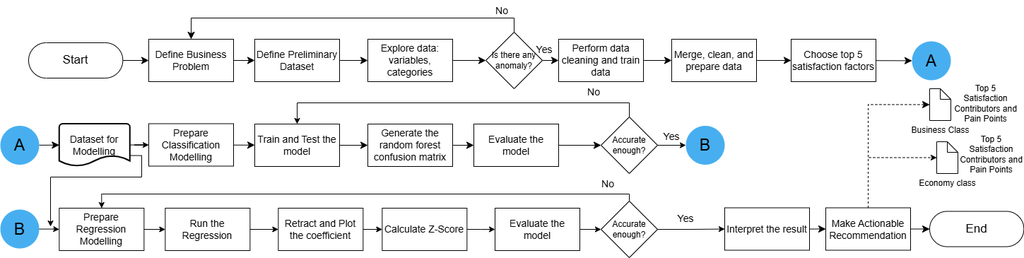

```r
file_path <- "Workflow_Group17.png"
knitr::include_graphics(file_path)
```

## 1.6 Reflection and Limitation

In this research, we aim to predict **whether future customer would be satisfied given the details of service** by determining **the aspects of service that are important towards customer satisfaction.** From the dataset, we hypothesize that service characteristics such as arrival and departure delays, on-board service, and comfort play a significant role towards customer satisfaction.

Given that the dataset does not provide information on the specific airline or ticket pricing, we will focus to analyzing the service-related factors that universally impact passenger satisfaction. Understanding and preparing the the dataset will be crucial, as it may contain missing values or quality issues. Hence, we will dedicate the next section on data exploration and preparation. In doing so, we will first visualize the variables to get an understanding of the distributions.

# 2 Data Exploration and Preparation

In this chapter, we will use visual and descriptive data exploration methods to gain a deeper understanding of the distributions and the characteristics of variables in our dataset. We will begin by cleaning the data from any null variables, as well has handle outliers in the data. Later in this chapter, we will continue to explore each variable and interpret features. Finally, we will conduct initial plotting of the data to show how the features are correlated to each other.

## 2.1 Data Cleaning and Preparation

We will start the exploration phase by checking for missing data using the `is.na()` function.

```r
# Check for missing values
any(is.na(data))
```

```
## [1] TRUE
```

```r
# Compute percentage of missing values in each column
colMeans(is.na(data))
```

```
##                                     ID                                 Gender
##                             0.00000000                             0.00000000
##                                    Age                          Customer.Type
##                             0.00000000                             0.00000000
##                         Type.of.Travel                                  Class
##                             0.00000000                             0.00000000
##                        Flight.Distance                        Departure.Delay
##                             0.00000000                             0.00000000
##                          Arrival.Delay Departure.and.Arrival.Time.Convenience
##                             0.00302587                             0.00000000
##                 Ease.of.Online.Booking                       Check.in.Service
##                             0.00000000                             0.00000000
##                        Online.Boarding                          Gate.Location
##                             0.00000000                             0.00000000
##                       On.board.Service                           Seat.Comfort
##                             0.00000000                             0.00000000
##                       Leg.Room.Service                            Cleanliness
##                             0.00000000                             0.00000000
##                         Food.and.Drink                      In.flight.Service
##                             0.00000000                             0.00000000
##                 In.flight.Wifi.Service                In.flight.Entertainment
##                             0.00000000                             0.00000000
##                       Baggage.Handling                           Satisfaction
##                             0.00000000                             0.00000000
```

```r
# Replace NA values in Arrival.Delay with 0
data$Departure.Delay = as.numeric(data$Departure.Delay)
data$Arrival.Delay[is.na(data$Arrival.Delay)] <-0

# Check if there are any remaining NA values
any(is.na(data))
```

```
## [1] FALSE
```

We succesfully replace the null values in the dataset. Let’s check for numerical outliers using the `summary()` function, we will look for major differences between the median and the mean.

```r
# Extract summary statistics for numerical columns
numerical_summary <- data.frame(t(sapply(data[sapply(data, is.numeric)], summary)))

# Add a column to calculate the difference between mean and median
numerical_summary$Mean_Median_Difference <- abs(numerical_summary$Mean - numerical_summary$Median)

# Tabulate the output
knitr::kable(numerical_summary, caption = "Summary of Numerical Columns with Mean-Median Differences")
```

Summary of Numerical Columns with Mean-Median Differences

|  | Min. | X1st.Qu. | Median | Mean | X3rd.Qu. | Max. | Mean_Median_Difference |
| --- | --- | --- | --- | --- | --- | --- | --- |
| ID | 1 | 32470.75 | 64940.5 | 64940.500000 | 97410.25 | 129880 | 0.0000000 |
| Age | 7 | 27.00 | 40.0 | 39.427957 | 51.00 | 85 | 0.5720434 |
| Flight.Distance | 31 | 414.00 | 844.0 | 1190.316392 | 1744.00 | 4983 | 346.3163921 |
| Departure.Delay | 0 | 0.00 | 0.0 | 14.713713 | 12.00 | 1592 | 14.7137127 |
| Arrival.Delay | 0 | 0.00 | 0.0 | 15.045465 | 13.00 | 1584 | 15.0454650 |
| Departure.and.Arrival.Time.Convenience | 0 | 2.00 | 3.0 | 3.057599 | 4.00 | 5 | 0.0575993 |
| Ease.of.Online.Booking | 0 | 2.00 | 3.0 | 2.756876 | 4.00 | 5 | 0.2431244 |
| Check.in.Service | 0 | 3.00 | 3.0 | 3.306267 | 4.00 | 5 | 0.3062673 |
| Online.Boarding | 0 | 2.00 | 3.0 | 3.252633 | 4.00 | 5 | 0.2526332 |
| Gate.Location | 0 | 2.00 | 3.0 | 2.976925 | 4.00 | 5 | 0.0230751 |
| On.board.Service | 0 | 2.00 | 4.0 | 3.383023 | 4.00 | 5 | 0.6169772 |
| Seat.Comfort | 0 | 2.00 | 4.0 | 3.441361 | 5.00 | 5 | 0.5586387 |
| Leg.Room.Service | 0 | 2.00 | 4.0 | 3.350878 | 4.00 | 5 | 0.6491223 |
| Cleanliness | 0 | 2.00 | 3.0 | 3.286326 | 4.00 | 5 | 0.2863258 |
| Food.and.Drink | 0 | 2.00 | 3.0 | 3.204774 | 4.00 | 5 | 0.2047736 |
| In.flight.Service | 0 | 3.00 | 4.0 | 3.642193 | 5.00 | 5 | 0.3578072 |
| In.flight.Wifi.Service | 0 | 2.00 | 3.0 | 2.728696 | 4.00 | 5 | 0.2713043 |
| In.flight.Entertainment | 0 | 2.00 | 4.0 | 3.358077 | 4.00 | 5 | 0.6419233 |
| Baggage.Handling | 1 | 3.00 | 4.0 | 3.632114 | 5.00 | 5 | 0.3678857 |

```r
remove(numerical_summary)
```

We notice that there are large outliers in the Flight Distance, as well as in Arrival and Departure Delay. Let’s see in the boxplot format :

**Flight Distance**

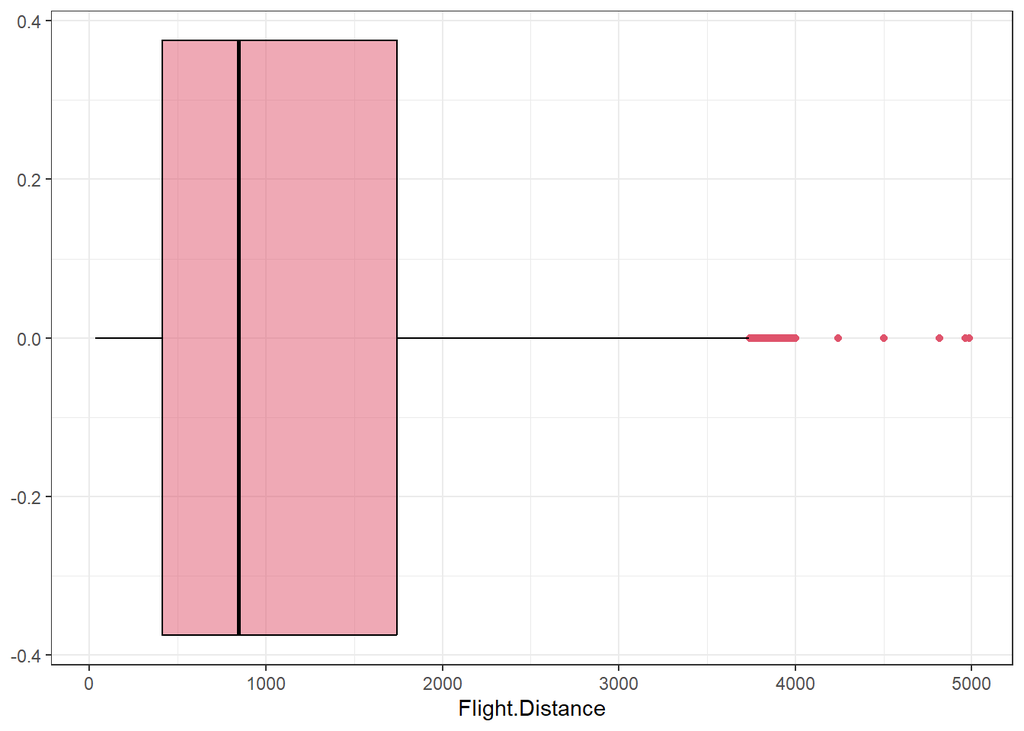

```r
# Boxplot for Flight Distance
ggplot(data, aes(x=Flight.Distance)) +
geom_boxplot(fill = 2,alpha = 0.5,color = 1,outlier.colour = 2) +
theme_bw()
```

**Departure Delay**

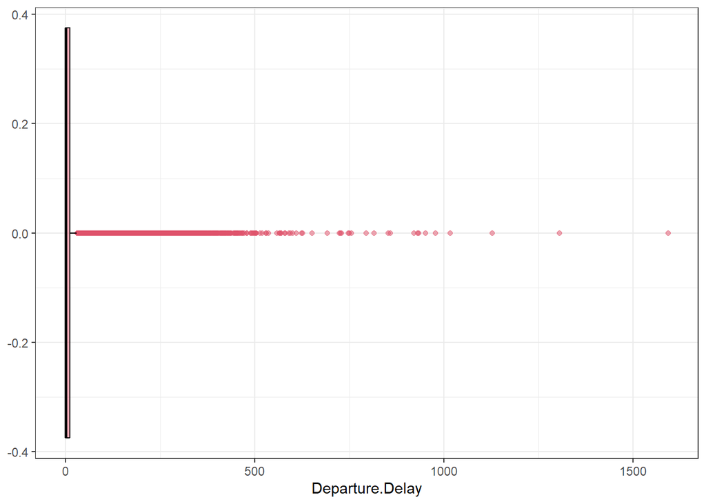

```r
# Boxplot for Departure Delay
ggplot(data, aes(x=Departure.Delay)) +
geom_boxplot(fill = 2,alpha = 0.5,color = 1,outlier.colour = 2) +
theme_bw()
```

**Arrival Delay**

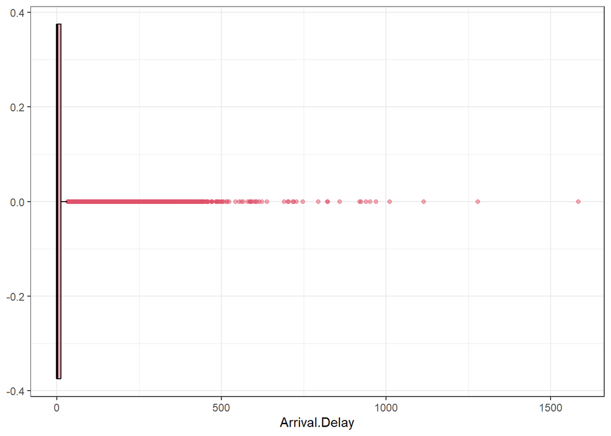

```r
# Boxplot for Arrival Delay
ggplot(data, aes(x=Arrival.Delay)) +
geom_boxplot(fill = 2,alpha = 0.5,color = 1,outlier.colour = 2) +
theme_bw()
```

From the boxplots above, we can see that Flight Distance is slightly skewed while Arrival Delay and Departure Delay is heavily skewed. We will use median imputation, which is appropriate when the distribution of the data is skewed.

```r
# Imputation of flight.distance variable
data$Flight.Distance[which(
  data$Flight.Distance > (quantile(data$Flight.Distance, 0.75, na.rm = TRUE) + 1.5 * IQR(data$Flight.Distance, na.rm = TRUE))
)] <- median(data$Flight.Distance, na.rm = TRUE)

# Imputation of arrival.delay variable
data$Arrival.Delay[which(
  data$Arrival.Delay > (quantile(data$Arrival.Delay, 0.75, na.rm = TRUE) + 1.5 * IQR(data$Arrival.Delay, na.rm = TRUE))
)] <- median(data$Arrival.Delay, na.rm = TRUE)

# Imputation of departure.delay variable
data$Departure.Delay[which(
  data$Departure.Delay > (quantile(data$Departure.Delay, 0.75, na.rm = TRUE) + 1.5 * IQR(data$Departure.Delay, na.rm = TRUE))
)] <- median(data$Departure.Delay, na.rm = TRUE)
```

Now let’s check the distribution of the data after the imputation.

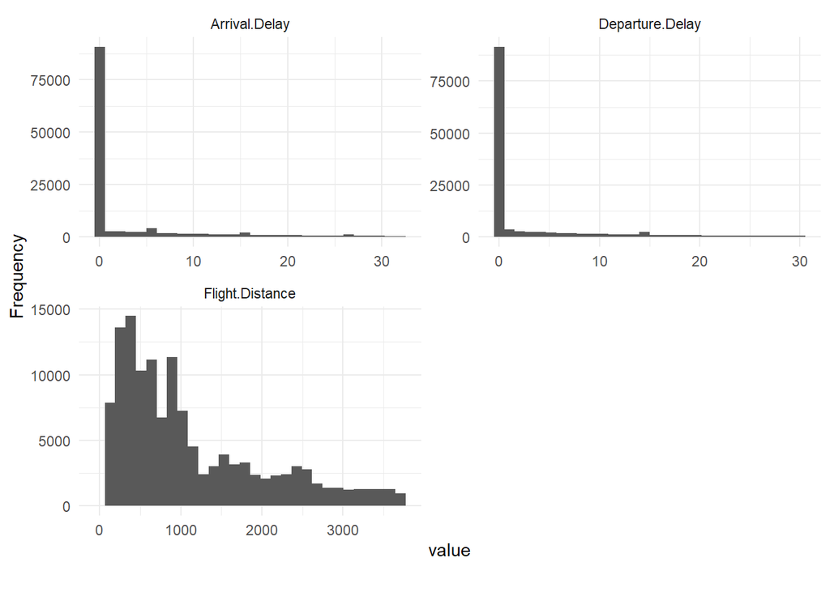

```r
plot_histogram(data[ , c('Flight.Distance','Arrival.Delay','Departure.Delay')], ncol=2,ggtheme = theme_minimal())
```

Below, we will also take a look again at the boxplots for Departure Delay and Arrival Delay. Note that before the imputation, the plots were skewed to the point that the boxes were almost no longer visible.

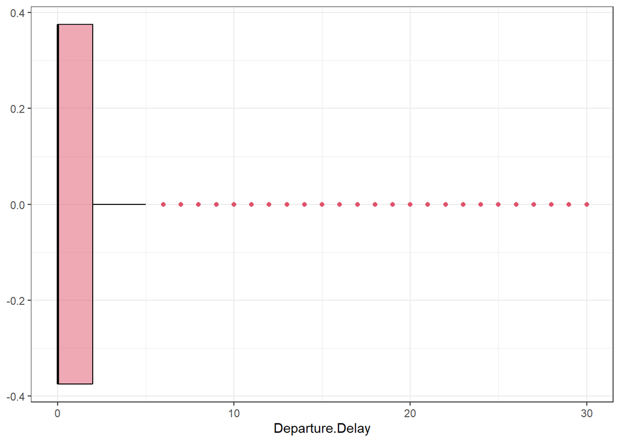

```r
# Boxplot for Departure Delay after imputation
ggplot(data, aes(x=Departure.Delay)) +
geom_boxplot(fill = 2,alpha = 0.5,color = 1,outlier.colour = 2) +
theme_bw()
```

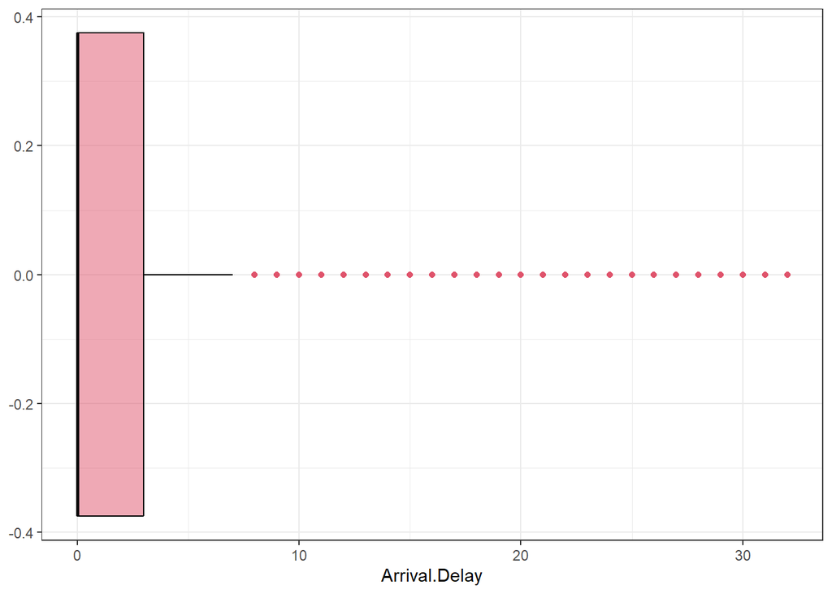

```r
# Boxplot for Arrival Delay after imputation
ggplot(data, aes(x=Arrival.Delay)) +
geom_boxplot(fill = 2,alpha = 0.5,color = 1,outlier.colour = 2) +
theme_bw()
```

## 2.2 Data Exploration

In this subchapter, we will begin by conducting descriptive univariate data analysis which is followed by association between numerical and categorical variables.

### 2.2.1 Univariate Data Analysis

Now we visualize the distribution in each categorical column

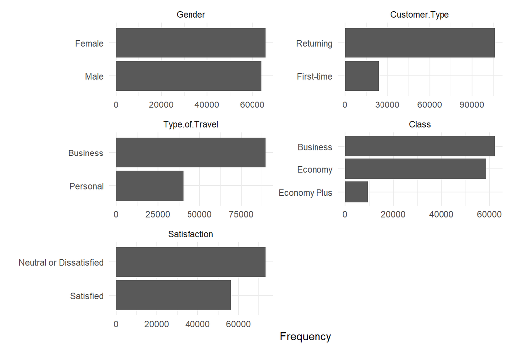

```r
# Bar chart will be used for categorical data
plot_bar(data, ncol=2, order_bar=TRUE, ggtheme = theme_minimal())
```

We can see that the gender distribution is equal. Furthermore, the majority type of travel is business which is also reflected in the customer type, where the majority is returning customers rather than first-time. Hence, increasing satisfaction of loyal customers will bring significant impact to the overall of airline customer satisfaction rate. Next, we will visualize the distribution in each numerical column. The ID column is left out as it is just a list of numbers.

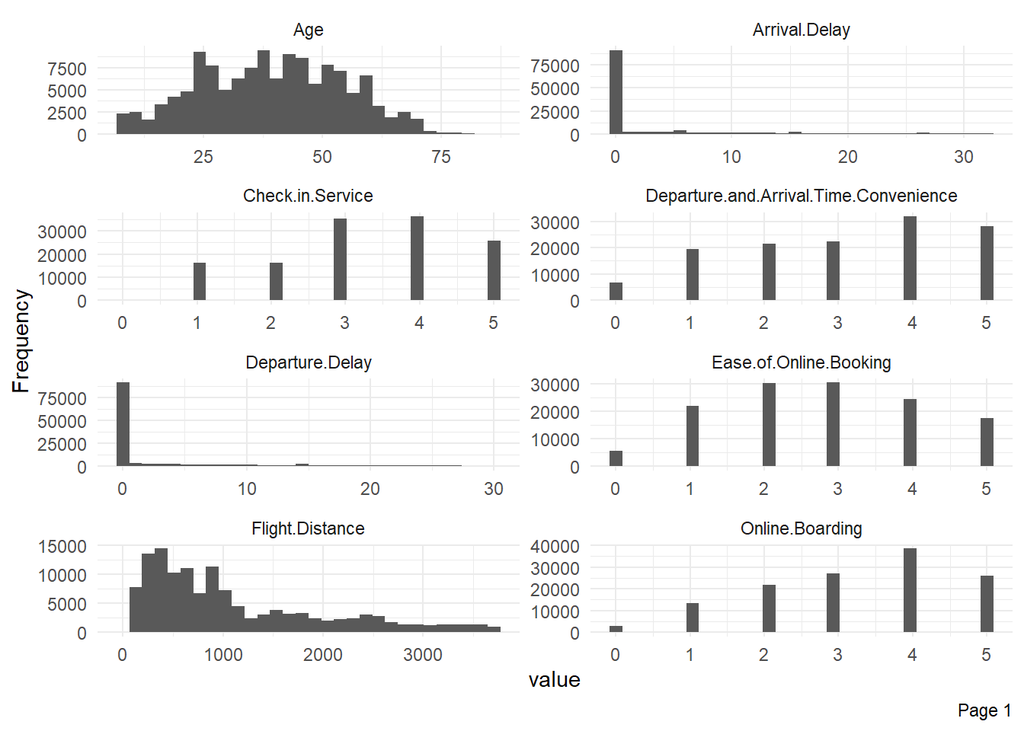

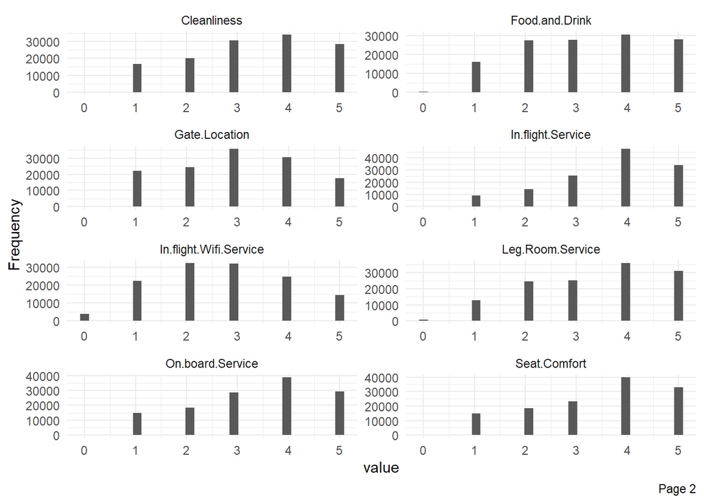

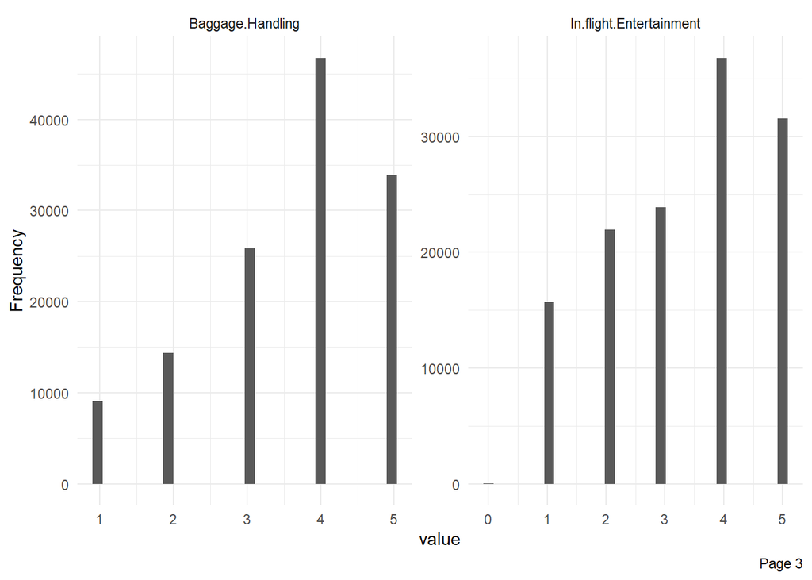

```r
# Numerical variables are visualized using histogram
plot_histogram(data[ , !names(data) %in% "ID"], ncol=2, ggtheme = theme_minimal())
```

From the visualizations above, it is not immediately clear which variables may be strongly influencing each other. Hence, we will continue the exploration by analyzing the associations between numerical variables.

### 2.2.2 Association Between Two Numerical Variable

Now we will analyze the association between two numerical variables. We will use the `corrplot` package to visualize the correlation matrix of the numerical variables in the dataset. The correlation matrix will help us identify any strong correlations between the numerical variables.

```r
numeric_data <- data[sapply(data, is.numeric)]
numeric_data <- na.omit(numeric_data)

# Compute correlation matrix
cor_matrix <- cor(numeric_data)

# Print the correlation matrix
print(cor_matrix)
```

```
##                                                   ID           Age
## ID                                      1.0000000000  0.0203221824
## Age                                     0.0203221824  1.0000000000
## Flight.Distance                         0.1022584170  0.0893852005
## Departure.Delay                         0.0660485697 -0.0054671682
## Arrival.Delay                           0.0224045458 -0.0074931552
## Departure.and.Arrival.Time.Convenience -0.0021920038  0.0369602634
## Ease.of.Online.Booking                  0.0134000186  0.0225652378
## Check.in.Service                        0.0793252087  0.0334753085
## Online.Boarding                         0.0555378869  0.2075724231
## Gate.Location                          -0.0001130817 -0.0003980758
## On.board.Service                        0.0555016852  0.0570776207
## Seat.Comfort                            0.0521641921  0.1591359282
## Leg.Room.Service                        0.0440883552  0.0391190045
## Cleanliness                             0.0240475050  0.0525651010
## Food.and.Drink                         -0.0005103864  0.0231937123
## In.flight.Service                       0.0787930170 -0.0513466111
## In.flight.Wifi.Service                 -0.0230963975  0.0161162160
## In.flight.Entertainment                 0.0016204382  0.0749465159
## Baggage.Handling                        0.0745692684 -0.0479910406
##                                        Flight.Distance Departure.Delay
## ID                                         0.102258417    0.0660485697
## Age                                        0.089385200   -0.0054671682
## Flight.Distance                            1.000000000    0.0144629202
## Departure.Delay                            0.014462920    1.0000000000
## Arrival.Delay                             -0.001644757    0.4520762051
## Departure.and.Arrival.Time.Convenience    -0.013972714   -0.0014122443
## Ease.of.Online.Booking                     0.063665582   -0.0025286991
## Check.in.Service                           0.070694837   -0.0023126209
## Online.Boarding                            0.201323559   -0.0113489110
## Gate.Location                              0.005805883    0.0016946084
## On.board.Service                           0.104653887   -0.0071698780
## Seat.Comfort                               0.147639915   -0.0025332906
## Leg.Room.Service                           0.126539738   -0.0085318492
## Cleanliness                                0.090210968   -0.0042499056
## Food.and.Drink                             0.054242099   -0.0018817431
## In.flight.Service                          0.056544236    0.0005323097
## In.flight.Wifi.Service                     0.007242013   -0.0142761646
## In.flight.Entertainment                    0.120349680   -0.0102650206
## Baggage.Handling                           0.061386622   -0.0072871564
```

[output cut: 165 more lines]

```
## Arrival.Delay                                     -0.026413185     -0.024396322
## Departure.and.Arrival.Time.Convenience            -0.008380014      0.070833036
## Ease.of.Online.Booking                             0.046563505      0.039148282
## Check.in.Service                                   0.119554033      0.234503128
## Online.Boarding                                    0.283921540      0.083541489
## Gate.Location                                      0.002740830      0.000971931
## On.board.Service                                   0.418573575      0.520295528
## Seat.Comfort                                       0.611836657      0.074619552
## Leg.Room.Service                                   0.300397442      0.371454684
## Cleanliness                                        0.692510538      0.097071490
## Food.and.Drink                                     0.623460937      0.035320744
## In.flight.Service                                  0.406093608      0.629237197
## In.flight.Wifi.Service                             0.207801648      0.120375901
## In.flight.Entertainment                            1.000000000      0.379122757
## Baggage.Handling                                   0.379122757      1.000000000
```

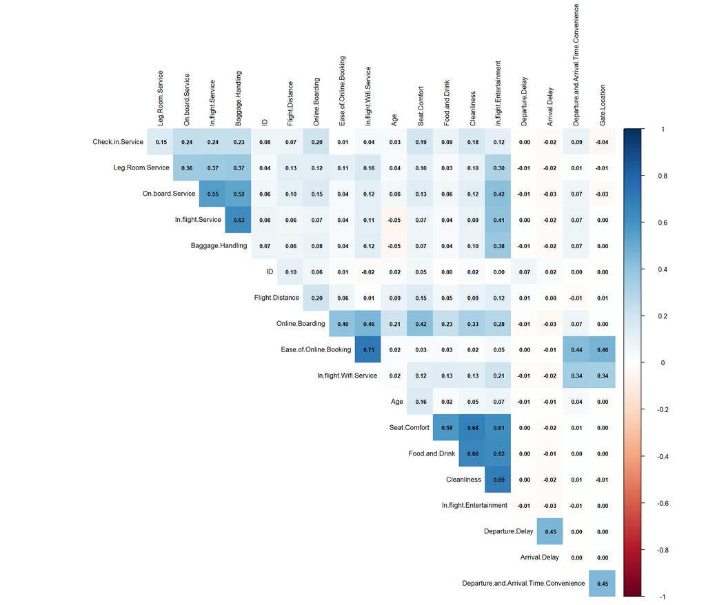

```r
# Visualize the correlation matrix
options(repr.plot.width=14, repr.plot.height=12)
corrplot(cor_matrix,
         method = "color",
         type = "upper",
         order = "hclust",
         tl.col = "black",
         tl.cex = 0.8,
         number.cex = 0.7,
         addCoef.col = "black",
         diag = FALSE)
```

Then we will filter the correlation matrix to find strong correlations (greater than 0.5 or less than -0.5) between numerical variables.

```r
# Discover strong correlation
cor_matrix_flat <- as.data.frame(as.table(cor_matrix))
filtered <- subset(cor_matrix_flat, abs(Freq) > 0.5 & Var1 != Var2)
filtered <- filtered[!duplicated(t(apply(filtered[, 1:2], 1, sort))), ]

print(filtered)
```

```
##                        Var1                   Var2      Freq
## 131  In.flight.Wifi.Service Ease.of.Online.Booking 0.7148068
## 206       In.flight.Service       On.board.Service 0.5515688
## 209        Baggage.Handling       On.board.Service 0.5202955
## 223             Cleanliness           Seat.Comfort 0.6796130
## 224          Food.and.Drink           Seat.Comfort 0.5758462
## 227 In.flight.Entertainment           Seat.Comfort 0.6118367
## 262          Food.and.Drink            Cleanliness 0.6580539
## 265 In.flight.Entertainment            Cleanliness 0.6925105
## 284 In.flight.Entertainment         Food.and.Drink 0.6234609
## 304        Baggage.Handling      In.flight.Service 0.6292372
```

**In-flight Service vs On-board Service (in %)**

After we have analyzed the correlation between numerical variables, we will now analyze the association between categorical variables. We will use a heatmap to visualize the association between two categorical variables. The heatmap will show the percentage of each combination of ratings for the two variables.

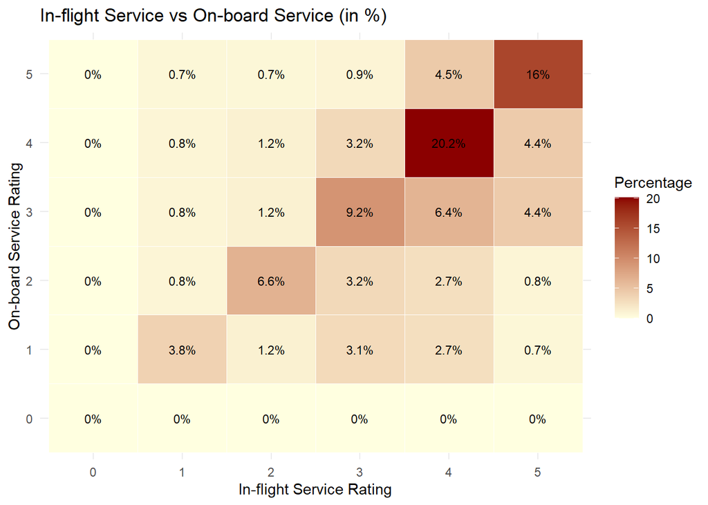

```r
count_data <- as.data.frame(table(data$In.flight.Service, data$On.board.Service))
count_data$Percent <- round(100 * count_data$Freq / sum(count_data$Freq), 1)

# Plot heatmap
ggplot(count_data, aes(x = Var1, y = Var2, fill = Percent)) +
  geom_tile(color = "white") +
  geom_text(aes(label = paste0(Percent, "%")), color = "black", size = 3) +
  scale_fill_gradient(low = "lightyellow", high = "darkred") +
  labs(title = "In-flight Service vs On-board Service (in %)",
       x = "In-flight Service Rating",
       y = "On-board Service Rating",
       fill = "Percentage") +
  theme_minimal()
```

The heatmap above shows a strong positive correlation between In-flight Service and On-board Service. This suggests that passengers who rate one aspect of the service highly also tend to rate the other positively. Darker shades indicate higher percentages, with the highest concentration (20.2%) at ( In-flight Service= 4, On-board Service = 4), suggesting a tendency for passengers to rate both aspects positively together.

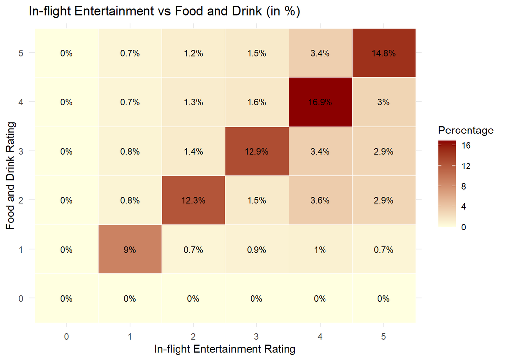

```r
count_data <- as.data.frame(table(data$In.flight.Entertainment, data$Food.and.Drink))
count_data$Percent <- round(100 * count_data$Freq / sum(count_data$Freq), 1)

# Plot heatmap
ggplot(count_data, aes(x = Var1, y = Var2, fill = Percent)) +
  geom_tile(color = "white") +
  geom_text(aes(label = paste0(Percent, "%")), color = "black", size = 3) +
  scale_fill_gradient(low = "lightyellow", high = "darkred") +
  labs(title = "In-flight Entertainment vs Food and Drink (in %)",
       x = "In-flight Entertainment Rating",
       y = "Food and Drink Rating",
       fill = "Percentage") +
  theme_minimal()
```

From the heatmap above, we can see that there is a strong positive correlation between In-flight Entertainment and Food and Drink. he most common rating combination is (4,4), accounting for 16.9% of responses, followed by (5,5) with 14.8%, indicating This suggests that passengers who rate the in-flight entertainment highly also tend to rate the food and drink positively.